# biopixR: Extracting Insights from Biological Images

24 April 2024

# Summary

Imaging is crucial for data acquisition in biological laboratories and the broader field of life sciences. It provides essential insights into cells (Rödiger et al. 2018; Schneider et al. 2019), biomarkers (Vafajoo et al. 2018), stress responses (Korkmaz, Debelec Butuner, and Roggenbuck 2018), and gene expression (Brenner et al. 2000), which are necessary for diagnostics and predicting disease outcomes. Microbead technology is a highly promising field for gathering complex information in a straightforward, rapid, and flexible manner (Rödiger et al. 2014). These assays that use microbeads rely on visualization methods, such as microscopy (Ding et al. 2020). Therefore, it is necessary to have user-friendly image processing software to effectively analyze the data.

`biopixR` is an `R` package (R Core Team 2023a) that utilizes the `imager` (Barthelmé and Tschumperlé 2019) and `magick` (Ooms 2024) packages to perform various image processing tasks, such as preprocessing, object counting, feature extraction, and filtering. It is designed for medium-throughput analysis and generates log files to track the analytical process in detail. Core functionality of `biopixR` was used in a recent study (Geithe et al. 2024) to perform quality control on microbeads. `biopixR` can extract various types of information, including *object size*, *quantity*, *shape* and *intensity*. The package includes an algorithm that fills gaps between lines and reconnects loose ends, making complex images accessible for later analysis.

# Statement of need

Extracting valuable information from complex biological images in a quick, reliable, and straightforward manner presents a significant challenge. A critical aspect of this process is the quantification of objects within the images.

Quantification is crucial for deriving biological insights from experiments, as demonstrated in bead-assays. This method is highly promising due to its extensive multiplexing abilities, high-throughput capacity, shortened analysis time, and minimal sample requirements (Rödiger et al. 2014). Detection methods for microbeads include flow cytometry, microfluidics, and image-based techniques (Choi et al. 2019). A user-friendly tool integrated into R could be highly beneficial for comprehensive analysis, particularly when combined with statistical analysis and visualization techniques. Advancements in smart device imaging and chip development for bead-assays are improving the use of microbeads in point-of-care testing (POCT) and disease diagnosis (Dinter et al. 2019; Zhang et al. 2019). This progress underscores the need for direct extraction of biological information from images, eliminating the dependence on complex laboratory equipment. Additionally, software capable of extracting attributes like fluorescence intensity, size, and shape enables the encoding of beads (Zhang et al. 2019). This capability makes it possible to differentiate between populations, thus significantly enhancing the scope for multiplexing.

Bead-based ePCR assays, like other bead-based assays, are often analyzed using fluorescence activated cell sorting (FACS) (Fraser et al. 2015). However, this software could enable the analysis of bead-based ePCR through imaging techniques, as droplets can be imaged and altered to appear distinct by closing gaps between their contours. The package could be applied in various domains, including wastewater assessment, to investigate the presence of microplastics in water (Ding et al. 2020). It could also be used in microbead-based drug delivery systems to facilitate real-time detection and localization (Bannerman and Wan 2016).

Therefore, the `biopixR` package for `R` is needed, as it automates the evaluation process and enables high-throughput analysis directly from images, simplifying analytical procedures and opening up new experimental possibilities.

# Software engineering

`biopixR` (0.2.4, [LGLP-3.0license](https://www.gnu.org/licenses/lgpl-3.0.en.html)) is an `R` package (S3 class systen). The choice of `R` as a programming language for image processing is based on its open-source framework, advanced packages such as `imager` (Barthelmé and Tschumperlé 2019) and `magick` (Ooms 2024), and its strong support for reproducible research (Xie 2019). These features collectively provide a sophisticated environment for image analysis and editing, with the added advantage of community-driven improvements (Chambers 2008). `R`’s integration of analysis with documentation ensures methodological precision and transparency in scientific research, making it a preferred choice for complex image processing tasks. The `biopixR` package underwent quality control through unit testing using the `testthat` package (Wickham 2011), ensuring its reliability.

## Functions

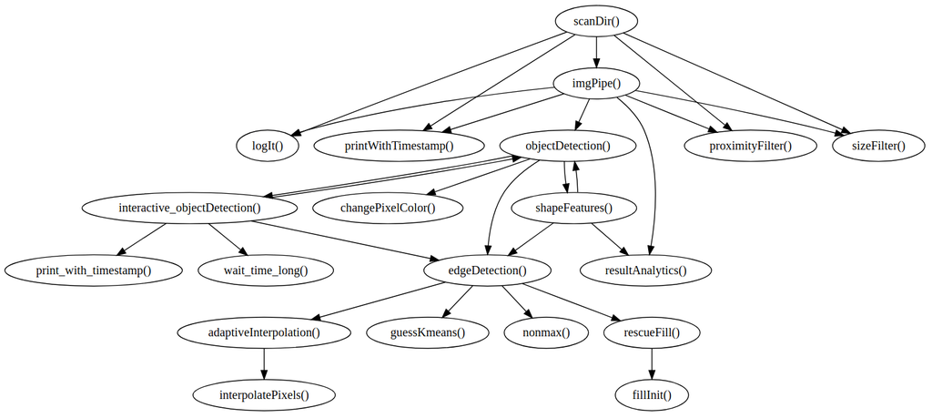

Dependency graph of the functions present in the `biopixR` package. Showing the levels of complexity by showing the descendants and ancestors of the `imgPipe()` function. The figure was created using the `foodwebr` package from Appleton-Fox (2022) (package version 0.1.1, RStudio 2023.09.0+463, R 4.3.2 on Linux, Ubuntu 22.04.3 LTS).

The `biopixR` package in R is intended for analyzing bioimage data, with a specific focus on the analysis and characterization of bead microparticles. The package provides tools for image preprocessing, segmentation, feature extraction, and visualization. It supports automation for high-throughput analysis, utilizing algorithms to identify spherical objects, extract their features, and implement interactive tools for threshold and smoothing factor selection. Furthermore, it offers features for removing clumped or closely positioned particles to prevent inaccurate results, with the goal of improving the analysis of microparticles in diverse scientific disciplines.

In addition to the `shapeFeatures()` function, capable of extracting shape-related information from detected objects and grouping them using the SOM (Self-Organizing Map) algorithm (Wehrens and Buydens 2007), there’s also the `imgPipe()` function. This latter function serves as a comprehensive pipeline for image analysis, offering a variety of selectable functions:

- `importImage()`, a wrapper import function combining the `imager` (Barthelmé and Tschumperlé 2019) and `magick` (Ooms 2024) packages.
- `edgeDetection()`, a combination of a Canny edge detector and gap filling (Barthelmé and Tschumperlé 2019),
- `objectDetection()`, detects objects in an image by identifying their coordinates,
- `sizeFilter()`, eliminates objects that exceed or fall below a certain size threshold,
- `proximityFilter()`, filters objects that are in close proximity to each other,
- `resultAnalytics()`, summarizes the extracted features in a clear and concise manner.

The `biopixR` package includes functions for analyzing entire directories, allowing for high-throughput analysis. Making feature extraction and image clustering easily accessible:

- `haralickCluster()`, extracts Haralick features and cluster using PAM (Partitioning Around Medoids) (Haralick, Shanmugam, and Dinstein 1973; Carlson 2018; Maechler et al. 2023),
- `scanDir()`, utilizing the pipeline for whole directory analysis (under development).

The `fillLineGaps()` algorithm, along with helper functions:

- `interpolatePixels()`, calculates the coordinates required to connect two given points,
- `adaptiveInterpolation()`, searches a given radius surrounding a line end for contours and connects them,

addresses the issue of discontinuous edges by iteratively scanning for line ends within the image and reconnecting them to adjacent contours.

Examples demonstrating the use of Brauckhoff, Rödiger, and Kieffer (2024) for image analysis tasks can be found in the package’s vignette.

## Graphical User Interface:

The function `interactive_objectDetection()` initiates a graphical user interface (GUI) that utilizes the Tcl/Tk framework (R Core Team 2023b), enabling users to adjust the threshold and smoothing settings of the image.

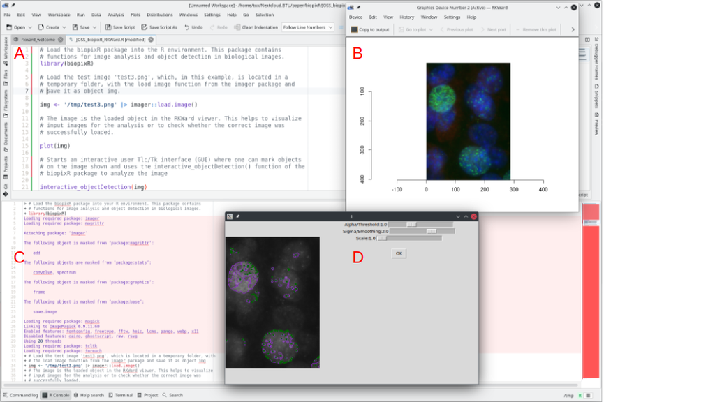

# Current status and outlook

The `biopixR` package was released on CRAN in March 2024. To ensure code quality, we employed various methodologies, including [Continuous Integration](https://github.com/Brauckhoff/biopixR/blob/main/.github/workflows/R-CMD-check.yml) (CI), unit testing (Wickham 2011), adherence to naming conventions (Bååth 2012), and the application of style guidelines (Wickham 2019). Although the package is relatively new, we are working to expand its features and evaluate its applicability using empirical research data from diverse sources. In addition, future developments will involve expanding its capabilities to identify DNA damage, particularly in the form of foci.

# Funding

The study was funded in part by the project Rubin: NeuroMiR (03RU1U051A, federal ministry of eduction and research, Germany).

# References

Appleton-Fox, Lewin. 2022. *Foodwebr: Visualise Function Dependencies*. https://github.com/lewinfox/foodwebr.

Bååth, Rasmus. 2012. “The State of Naming Conventions in R.” *The R Journal* 4 (2): 74–75. https://doi.org/10.32614/RJ-2012-018.

Bannerman, Dawn, and Wankei Wan. 2016. “Multifunctional Microbeads for Drug Delivery in TACE.” *Expert Opinion on Drug Delivery* 13 (9): 1289–1300. https://doi.org/10.1080/17425247.2016.1192122.

Barthelmé, Simon, and David Tschumperlé. 2019. “Imager: An r Package for Image Processing Based on CImg.” *Journal of Open Source Software* 4 (38): 1012. https://doi.org/10.21105/joss.01012.

Brauckhoff, Tim, Stefan Rödiger, and Coline Kieffer. 2024. “biopixR - Introduction [Vignette].” *Comprehensive R Archive Network*. https://cran.r-project.org/web/packages/biopixR/vignettes/biopixR.html.

Brenner, Sydney, Maria Johnson, John Bridgham, George Golda, David H. Lloyd, Davida Johnson, Shujun Luo, et al. 2000. “Gene Expression Analysis by Massively Parallel Signature Sequencing (MPSS) on Microbead Arrays.” *Nature Biotechnology* 18 (6): 630–34. https://doi.org/10.1038/76469.

Carlson, Joel. 2018. “’Radiomic’ Image Processing Toolbox.” *Comprehensive R Archive Network*. https://cran.r-project.org/package=radiomics.

Chambers, John. 2008. *Software for Data Analysis: Programming with r*. *Statistics and Computing*. Springer New York. https://doi.org/10.1007/978-0-387-75936-4.

Choi, Youngeun, Carsten Schmidt, Philip Tinnefeld, Ilko Bald, and Stefan Rödiger. 2019. “A New Reporter Design Based on DNA Origami Nanostructures for Quantification of Short Oligonucleotides Using Microbeads.” *Scientific Reports* 9 (1). https://doi.org/10.1038/s41598-019-41136-x.

Ding, Ning, Di An, Xiufeng Yin, and Yingxue Sun. 2020. “Detection and Evaluation of Microbeads and Other Microplastics in Wastewater Treatment Plant Samples.” *Environmental Science and Pollution Research* 27 (13): 15878–87. https://doi.org/10.1007/s11356-020-08127-2.

Dinter, Franziska, Michał Burdukiewicz, Peter Schierack, Werner Lehmann, Jörg Nestler, Gregory Dame, and Stefan Rödiger. 2019. “Simultaneous Detection and Quantification of DNA and Protein Biomarkers in Spectrum of Cardiovascular Diseases in a Microfluidic Microbead Chip.” *Analytical and Bioanalytical Chemistry* 411 (29): 7725–35. https://doi.org/10.1007/s00216-019-02199-x.

Fraser, Lewis, Andrew Kinghorn, Marco Tang, Yee-Wai Cheung, Bryce Lim, Shaolin Liang, Roderick Dirkzwager, and Julian Tanner. 2015. “Oligonucleotide Functionalised Microbeads: Indispensable Tools for High-Throughput Aptamer Selection.” *Molecules* 20 (12): 21298–312. https://doi.org/10.3390/molecules201219766.

Geithe, Christiane, Bo Zeng, Carsten Schmidt, Franziska Dinter, Dirk Roggenbuck, Werner Lehmann, Gregory Dame, Peter Schierack, Katja Hanack, and Stefan Rödiger. 2024. “A Multiplex Microchamber Diffusion Assay for the Antibody-Based Detection of microRNAs on Randomly Ordered Microbeads.” *Biosensors and Bioelectronics: X* 18 (June): 100484. https://doi.org/10.1016/j.biosx.2024.100484.

Haralick, Robert M., K. Shanmugam, and Its’Hak Dinstein. 1973. “Textural Features for Image Classification.” *IEEE Transactions on Systems, Man, and Cybernetics* SMC-3 (6): 610–21. https://doi.org/10.1109/tsmc.1973.4309314.

Korkmaz, Kemal Sami, Bilge Debelec Butuner, and Dirk Roggenbuck. 2018. “Detection of 8-OHdG as a Diagnostic Biomarker.” *Journal of Laboratory and Precision Medicine* 3 (November): 95–95. https://doi.org/10.21037/jlpm.2018.11.01.

Maechler, Martin, Peter Rousseeuw, Anja Struyf, Mia Hubert, and Kurt Hornik. 2023. *Cluster: Cluster Analysis Basics and Extensions*. https://CRAN.R-project.org/package=cluster.

Ooms, Jeroen. 2024. *Magick: Advanced Graphics and Image-Processing in r*. https://docs.ropensci.org/magick/ https://ropensci.r-universe.dev/magick.

R Core Team. 2023a. “R: A Language and Environment for Statistical Computing.” https://www.R-project.org/.

———. 2023b. “Tcl/Tk Interface.” https://CRAN.R-project.org/package=tcltk.

Rödiger, Stefan, Thomas Friedrichsmeier, Prasenjit Kapat, and Meik Michalke. 2012. “RKWard: A Comprehensive Graphical User Interface and Integrated Development Environment for Statistical Analysis with R.” *Journal of Statistical Software* 49 (9): 1–34. https://doi.org/10.18637/jss.v049.i09.

Rödiger, Stefan, Claudia Liebsch, Carsten Schmidt, Werner Lehmann, Ute Resch-Genger, Uwe Schedler, and Peter Schierack. 2014. “Nucleic Acid Detection Based on the Use of Microbeads: A Review.” *Microchimica Acta* 181 (11–12): 1151–68. https://doi.org/10.1007/s00604-014-1243-4.

Rödiger, Stefan, Marius Liefold, Madeleine Ruhe, Mark Reinwald, Eberhard Beck, and P. Markus Deckert. 2018. “Quantification of DNA Double-Strand Breaks in Peripheral Blood Mononuclear Cells from Healthy Donors Exposed to Bendamustine by an Automated yH2AX Assay—an Exploratory Study.” *Journal of Laboratory and Precision Medicine* 3 (May): 47–47. https://doi.org/10.21037/jlpm.2018.04.10.

Schneider, Jens, Romano Weiss, Madeleine Ruhe, Tobias Jung, Dirk Roggenbuck, Ralf Stohwasser, Peter Schierack, and Stefan Rödiger. 2019. “Open Source Bioimage Informatics Tools for the Analysis of DNA Damage and Associated Biomarkers.” *Journal of Laboratory and Precision Medicine* 4 (0): 1–27. https://doi.org/10.21037/jlpm.2019.04.05.

Vafajoo, Atieh, Azin Rostami, Sanam Foroutan Parsa, Reza Salarian, Navid Rabiee, Ghazal Rabiee, Mohammad Rabiee, et al. 2018. “Multiplexed Microarrays Based on Optically Encoded Microbeads.” *Biomedical Microdevices* 20 (3). https://doi.org/10.1007/s10544-018-0314-4.

Wehrens, Ron, and Lutgarde M. C. Buydens. 2007. “Self- and Super-Organizing Maps in R: The kohonen Package.” *Journal of Statistical Software* 21 (5): 1–19. https://doi.org/10.18637/jss.v021.i05.

Wickham, Hadley. 2011. “Testthat: Get Started with Testing.” *The R Journal* 3 (1): 5. https://doi.org/10.32614/rj-2011-002.

———. 2019. *Advanced r*. Second edition. Chapman & Hall/CRC the r Series. Boca Raton: CRC Press, Taylor & Francis Group.

Xie, Yihui. 2019. *R Markdown: The Definitive Guide*. Edited by Joseph J. Allaire and Garrett Grolemund. Chapman & Hall/CRC, the r Series. Boca Raton: CRC Press, Taylor & Francis Group.

Zhang, Jing, Swati Shikha, Qingsong Mei, Jinliang Liu, and Yong Zhang. 2019. “Fluorescent Microbeads for Point-of-Care Testing: A Review.” *Microchimica Acta* 186 (6). https://doi.org/10.1007/s00604-019-3449-y.

[^1]: Corresponding author